# Risk Factor Analysis

## Outcome Variable

**Outcome Variable:** stunted

## Predictor Variables

**Intervention Variable:** birthwt

**Adjustment Set:**

unadjusted

## Stratifying Variables

The analysis was stratified on these variable(s):

- agecat
- studyid
- country

## Data Summary

| agecat | studyid | country | birthwt | stunted | n_cell | n |
| --- | --- | --- | --- | --- | --- | --- |
| Birth | CMC-V-BCS-2002 | INDIA | Normal or high birthweight | 0 | 71 | 92 |
| Birth | CMC-V-BCS-2002 | INDIA | Normal or high birthweight | 1 | 10 | 92 |
| Birth | CMC-V-BCS-2002 | INDIA | Low birthweight | 0 | 4 | 92 |
| Birth | CMC-V-BCS-2002 | INDIA | Low birthweight | 1 | 7 | 92 |
| Birth | CMIN | BANGLADESH | Normal or high birthweight | 0 | 13 | 26 |
| Birth | CMIN | BANGLADESH | Normal or high birthweight | 1 | 1 | 26 |
| Birth | CMIN | BANGLADESH | Low birthweight | 0 | 4 | 26 |
| Birth | CMIN | BANGLADESH | Low birthweight | 1 | 8 | 26 |
| Birth | COHORTS | GUATEMALA | Normal or high birthweight | 0 | 695 | 784 |
| Birth | COHORTS | GUATEMALA | Normal or high birthweight | 1 | 22 | 784 |
| Birth | COHORTS | GUATEMALA | Low birthweight | 0 | 43 | 784 |
| Birth | COHORTS | GUATEMALA | Low birthweight | 1 | 24 | 784 |
| Birth | COHORTS | INDIA | Normal or high birthweight | 0 | 5059 | 6638 |
| Birth | COHORTS | INDIA | Normal or high birthweight | 1 | 209 | 6638 |
| Birth | COHORTS | INDIA | Low birthweight | 0 | 787 | 6638 |
| Birth | COHORTS | INDIA | Low birthweight | 1 | 583 | 6638 |
| Birth | COHORTS | PHILIPPINES | Normal or high birthweight | 0 | 2643 | 3004 |
| Birth | COHORTS | PHILIPPINES | Normal or high birthweight | 1 | 66 | 3004 |
| Birth | COHORTS | PHILIPPINES | Low birthweight | 0 | 181 | 3004 |
| Birth | COHORTS | PHILIPPINES | Low birthweight | 1 | 114 | 3004 |
| Birth | CONTENT | PERU | Normal or high birthweight | 0 | 2 | 2 |
| Birth | CONTENT | PERU | Normal or high birthweight | 1 | 0 | 2 |
| Birth | CONTENT | PERU | Low birthweight | 0 | 0 | 2 |
| Birth | CONTENT | PERU | Low birthweight | 1 | 0 | 2 |
| Birth | EE | PAKISTAN | Normal or high birthweight | 0 | 112 | 240 |
| Birth | EE | PAKISTAN | Normal or high birthweight | 1 | 48 | 240 |
| Birth | EE | PAKISTAN | Low birthweight | 0 | 28 | 240 |
| Birth | EE | PAKISTAN | Low birthweight | 1 | 52 | 240 |
| Birth | GMS-Nepal | NEPAL | Normal or high birthweight | 0 | 453 | 696 |
| Birth | GMS-Nepal | NEPAL | Normal or high birthweight | 1 | 23 | 696 |

[output cut: 282 more lines]

The following strata were considered:

- agecat: 24 months, studyid: CMC-V-BCS-2002, country: INDIA
- agecat: 24 months, studyid: CMIN, country: BANGLADESH
- agecat: 24 months, studyid: COHORTS, country: GUATEMALA
- agecat: 24 months, studyid: COHORTS, country: INDIA
- agecat: 24 months, studyid: COHORTS, country: PHILIPPINES
- agecat: 24 months, studyid: CONTENT, country: PERU
- agecat: 24 months, studyid: EE, country: PAKISTAN
- agecat: 24 months, studyid: GMS-Nepal, country: NEPAL
- agecat: 24 months, studyid: IRC, country: INDIA
- agecat: 24 months, studyid: JiVitA-3, country: BANGLADESH
- agecat: 24 months, studyid: JiVitA-4, country: BANGLADESH
- agecat: 24 months, studyid: Keneba, country: GAMBIA
- agecat: 24 months, studyid: MAL-ED, country: BANGLADESH
- agecat: 24 months, studyid: MAL-ED, country: BRAZIL
- agecat: 24 months, studyid: MAL-ED, country: INDIA
- agecat: 24 months, studyid: MAL-ED, country: NEPAL
- agecat: 24 months, studyid: MAL-ED, country: PERU
- agecat: 24 months, studyid: MAL-ED, country: SOUTH AFRICA
- agecat: 24 months, studyid: MAL-ED, country: TANZANIA, UNITED REPUBLIC OF
- agecat: 24 months, studyid: NIH-Birth, country: BANGLADESH
- agecat: 24 months, studyid: NIH-Crypto, country: BANGLADESH
- agecat: 24 months, studyid: PROBIT, country: BELARUS
- agecat: 24 months, studyid: PROVIDE, country: BANGLADESH
- agecat: 24 months, studyid: TanzaniaChild2, country: TANZANIA, UNITED REPUBLIC OF
- agecat: 24 months, studyid: ZVITAMBO, country: ZIMBABWE
- agecat: 6 months, studyid: CMC-V-BCS-2002, country: INDIA
- agecat: 6 months, studyid: CMIN, country: BANGLADESH
- agecat: 6 months, studyid: COHORTS, country: GUATEMALA
- agecat: 6 months, studyid: COHORTS, country: INDIA
- agecat: 6 months, studyid: COHORTS, country: PHILIPPINES
- agecat: 6 months, studyid: CONTENT, country: PERU
- agecat: 6 months, studyid: EE, country: PAKISTAN
- agecat: 6 months, studyid: GMS-Nepal, country: NEPAL
- agecat: 6 months, studyid: IRC, country: INDIA
- agecat: 6 months, studyid: JiVitA-3, country: BANGLADESH
- agecat: 6 months, studyid: JiVitA-4, country: BANGLADESH
- agecat: 6 months, studyid: Keneba, country: GAMBIA
- agecat: 6 months, studyid: MAL-ED, country: BANGLADESH
- agecat: 6 months, studyid: MAL-ED, country: BRAZIL
- agecat: 6 months, studyid: MAL-ED, country: INDIA
- agecat: 6 months, studyid: MAL-ED, country: NEPAL
- agecat: 6 months, studyid: MAL-ED, country: PERU
- agecat: 6 months, studyid: MAL-ED, country: SOUTH AFRICA
- agecat: 6 months, studyid: MAL-ED, country: TANZANIA, UNITED REPUBLIC OF
- agecat: 6 months, studyid: NIH-Birth, country: BANGLADESH
- agecat: 6 months, studyid: NIH-Crypto, country: BANGLADESH
- agecat: 6 months, studyid: PROBIT, country: BELARUS
- agecat: 6 months, studyid: PROVIDE, country: BANGLADESH
- agecat: 6 months, studyid: ResPak, country: PAKISTAN
- agecat: 6 months, studyid: SAS-CompFeed, country: INDIA
- agecat: 6 months, studyid: TanzaniaChild2, country: TANZANIA, UNITED REPUBLIC OF
- agecat: 6 months, studyid: ZVITAMBO, country: ZIMBABWE
- agecat: Birth, studyid: CMC-V-BCS-2002, country: INDIA
- agecat: Birth, studyid: CMIN, country: BANGLADESH
- agecat: Birth, studyid: COHORTS, country: GUATEMALA
- agecat: Birth, studyid: COHORTS, country: INDIA
- agecat: Birth, studyid: COHORTS, country: PHILIPPINES
- agecat: Birth, studyid: CONTENT, country: PERU
- agecat: Birth, studyid: EE, country: PAKISTAN
- agecat: Birth, studyid: GMS-Nepal, country: NEPAL
- agecat: Birth, studyid: IRC, country: INDIA
- agecat: Birth, studyid: JiVitA-3, country: BANGLADESH
- agecat: Birth, studyid: JiVitA-4, country: BANGLADESH
- agecat: Birth, studyid: Keneba, country: GAMBIA
- agecat: Birth, studyid: MAL-ED, country: BANGLADESH
- agecat: Birth, studyid: MAL-ED, country: BRAZIL
- agecat: Birth, studyid: MAL-ED, country: INDIA
- agecat: Birth, studyid: MAL-ED, country: NEPAL
- agecat: Birth, studyid: MAL-ED, country: PERU
- agecat: Birth, studyid: MAL-ED, country: SOUTH AFRICA
- agecat: Birth, studyid: MAL-ED, country: TANZANIA, UNITED REPUBLIC OF
- agecat: Birth, studyid: NIH-Birth, country: BANGLADESH
- agecat: Birth, studyid: NIH-Crypto, country: BANGLADESH
- agecat: Birth, studyid: PROBIT, country: BELARUS
- agecat: Birth, studyid: PROVIDE, country: BANGLADESH
- agecat: Birth, studyid: ResPak, country: PAKISTAN
- agecat: Birth, studyid: SAS-CompFeed, country: INDIA
- agecat: Birth, studyid: ZVITAMBO, country: ZIMBABWE

### Dropped Strata

Some strata were dropped due to rare outcomes:

- agecat: Birth, studyid: CMC-V-BCS-2002, country: INDIA
- agecat: Birth, studyid: CMIN, country: BANGLADESH
- agecat: Birth, studyid: CONTENT, country: PERU
- agecat: Birth, studyid: MAL-ED, country: BRAZIL
- agecat: Birth, studyid: MAL-ED, country: INDIA
- agecat: Birth, studyid: MAL-ED, country: NEPAL
- agecat: Birth, studyid: MAL-ED, country: PERU
- agecat: Birth, studyid: MAL-ED, country: SOUTH AFRICA
- agecat: Birth, studyid: MAL-ED, country: TANZANIA, UNITED REPUBLIC OF
- agecat: Birth, studyid: PROBIT, country: BELARUS
- agecat: Birth, studyid: ResPak, country: PAKISTAN
- agecat: 6 months, studyid: CMIN, country: BANGLADESH
- agecat: 6 months, studyid: CONTENT, country: PERU
- agecat: 6 months, studyid: MAL-ED, country: BRAZIL
- agecat: 6 months, studyid: MAL-ED, country: NEPAL
- agecat: 6 months, studyid: MAL-ED, country: TANZANIA, UNITED REPUBLIC OF
- agecat: 6 months, studyid: PROBIT, country: BELARUS
- agecat: 6 months, studyid: ResPak, country: PAKISTAN
- agecat: 24 months, studyid: CMIN, country: BANGLADESH
- agecat: 24 months, studyid: COHORTS, country: GUATEMALA
- agecat: 24 months, studyid: CONTENT, country: PERU
- agecat: 24 months, studyid: MAL-ED, country: BRAZIL
- agecat: 24 months, studyid: MAL-ED, country: PERU
- agecat: 24 months, studyid: MAL-ED, country: SOUTH AFRICA
- agecat: 24 months, studyid: MAL-ED, country: TANZANIA, UNITED REPUBLIC OF
- agecat: 24 months, studyid: PROBIT, country: BELARUS
- agecat: 24 months, studyid: TanzaniaChild2, country: TANZANIA, UNITED REPUBLIC OF

## Methods Detail

We’re interested in the causal parameters $E[Y_a]$ for all values of $a \in \mathcal{A}$. These parameters represent the mean outcome if, possibly contrary to fact, we intervened to set all units to have $A=a$. Under the randomization and positivity assumptions, these are identified by the statistical parameters $\psi_a=E_W[E_{Y|A,W}(Y|A=a,W)]$. In addition, we’re interested in the mean of $Y$, $E[Y]$ under no intervention (the observed mean). We will estimate these parameters by using SuperLearner to fit the relevant likelihood factors – $E_{Y|A,W}(Y|A=a,W)$ and $p(A=a|W)$, and then updating our likelihood fit using a joint TMLE.

For unadjusted analyses ($W=\{\}$), initial likelihoods were estimated using Lrnr_glm to estimate the simple $E(Y|A)$ and Lrnr_mean to estimate $p(A)$. For adjusted analyses, a small library containing Lrnr_glmnet, Lrnr_xgboost, and Lrnr_mean was used.

Having estimated these parameters, we will then use the delta method to estimate relative risks and attributable risks relative to a prespecified baseline level of $A$.

# Results Detail

## Results Plots

[figure not shown]

[figure not shown]

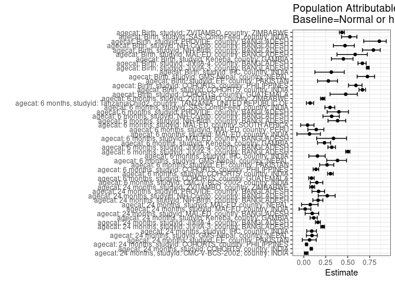

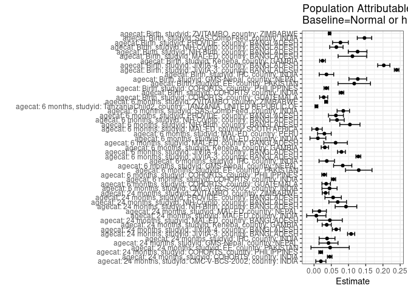

## Results Table

### Parameter: TSM

| agecat | studyid | country | intervention_level | baseline_level | estimate | ci_lower | ci_upper |
| --- | --- | --- | --- | --- | --- | --- | --- |
| Birth | COHORTS | GUATEMALA | Normal or high birthweight | NA | 0.0306834 | 0.0180520 | 0.0433148 |
| Birth | COHORTS | GUATEMALA | Low birthweight | NA | 0.3582090 | 0.2433267 | 0.4730912 |
| Birth | COHORTS | INDIA | Normal or high birthweight | NA | 0.0396735 | 0.0344022 | 0.0449448 |
| Birth | COHORTS | INDIA | Low birthweight | NA | 0.4255474 | 0.3993643 | 0.4517306 |
| Birth | COHORTS | PHILIPPINES | Normal or high birthweight | NA | 0.0243632 | 0.0185566 | 0.0301699 |
| Birth | COHORTS | PHILIPPINES | Low birthweight | NA | 0.3864407 | 0.3308657 | 0.4420156 |
| Birth | EE | PAKISTAN | Normal or high birthweight | NA | 0.3000000 | 0.2288452 | 0.3711548 |
| Birth | EE | PAKISTAN | Low birthweight | NA | 0.6500000 | 0.5452629 | 0.7547371 |
| Birth | GMS-Nepal | NEPAL | Normal or high birthweight | NA | 0.0483193 | 0.0290413 | 0.0675974 |
| Birth | GMS-Nepal | NEPAL | Low birthweight | NA | 0.4500000 | 0.3842135 | 0.5157865 |
| Birth | IRC | INDIA | Normal or high birthweight | NA | 0.0788644 | 0.0491553 | 0.1085734 |
| Birth | IRC | INDIA | Low birthweight | NA | 0.2878788 | 0.1785019 | 0.3972557 |
| Birth | JiVitA-3 | BANGLADESH | Normal or high birthweight | NA | 0.0892052 | 0.0834871 | 0.0949233 |
| Birth | JiVitA-3 | BANGLADESH | Low birthweight | NA | 0.6501667 | 0.6397735 | 0.6605599 |
| Birth | JiVitA-4 | BANGLADESH | Normal or high birthweight | NA | 0.1011673 | 0.0846262 | 0.1177084 |
| Birth | JiVitA-4 | BANGLADESH | Low birthweight | NA | 0.6591797 | 0.6249532 | 0.6934061 |
| Birth | Keneba | GAMBIA | Normal or high birthweight | NA | 0.0298165 | 0.0205963 | 0.0390367 |
| Birth | Keneba | GAMBIA | Low birthweight | NA | 0.1990950 | 0.1464309 | 0.2517591 |
| Birth | MAL-ED | BANGLADESH | Normal or high birthweight | NA | 0.0790960 | 0.0392497 | 0.1189424 |
| Birth | MAL-ED | BANGLADESH | Low birthweight | NA | 0.5555556 | 0.4227349 | 0.6883763 |
| Birth | NIH-Birth | BANGLADESH | Normal or high birthweight | NA | 0.0330969 | 0.0160353 | 0.0501586 |
| Birth | NIH-Birth | BANGLADESH | Low birthweight | NA | 0.4486486 | 0.3769209 | 0.5203764 |
| Birth | NIH-Crypto | BANGLADESH | Normal or high birthweight | NA | 0.0732143 | 0.0516250 | 0.0948036 |
| Birth | NIH-Crypto | BANGLADESH | Low birthweight | NA | 0.3488372 | 0.2775623 | 0.4201122 |
| Birth | PROVIDE | BANGLADESH | Normal or high birthweight | NA | 0.0124378 | 0.0015937 | 0.0232819 |
| Birth | PROVIDE | BANGLADESH | Low birthweight | NA | 0.3138686 | 0.2360885 | 0.3916487 |
| Birth | SAS-CompFeed | INDIA | Normal or high birthweight | NA | 0.1323851 | 0.0977557 | 0.1670146 |
| Birth | SAS-CompFeed | INDIA | Low birthweight | NA | 0.6745562 | 0.6137235 | 0.7353889 |
| Birth | ZVITAMBO | ZIMBABWE | Normal or high birthweight | NA | 0.0585129 | 0.0543008 | 0.0627249 |
| Birth | ZVITAMBO | ZIMBABWE | Low birthweight | NA | 0.3861126 | 0.3642262 | 0.4079990 |

[output cut: 72 more lines]

### Parameter: E(Y)

| agecat | studyid | country | intervention_level | baseline_level | estimate | ci_lower | ci_upper |
| --- | --- | --- | --- | --- | --- | --- | --- |
| Birth | COHORTS | GUATEMALA | NA | NA | 0.0586735 | 0.0422124 | 0.0751345 |
| Birth | COHORTS | INDIA | NA | NA | 0.1193130 | 0.1115144 | 0.1271117 |
| Birth | COHORTS | PHILIPPINES | NA | NA | 0.0599201 | 0.0514314 | 0.0684088 |
| Birth | EE | PAKISTAN | NA | NA | 0.4166667 | 0.3541635 | 0.4791698 |
| Birth | GMS-Nepal | NEPAL | NA | NA | 0.1752874 | 0.1470202 | 0.2035545 |
| Birth | IRC | INDIA | NA | NA | 0.1148825 | 0.0829051 | 0.1468600 |
| Birth | JiVitA-3 | BANGLADESH | NA | NA | 0.3289392 | 0.3215744 | 0.3363039 |
| Birth | JiVitA-4 | BANGLADESH | NA | NA | 0.3035778 | 0.2836422 | 0.3235133 |
| Birth | Keneba | GAMBIA | NA | NA | 0.0542838 | 0.0429232 | 0.0656445 |
| Birth | MAL-ED | BANGLADESH | NA | NA | 0.1904762 | 0.1397281 | 0.2412242 |
| Birth | NIH-Birth | BANGLADESH | NA | NA | 0.1595395 | 0.1304091 | 0.1886699 |
| Birth | NIH-Crypto | BANGLADESH | NA | NA | 0.1379781 | 0.1129774 | 0.1629789 |
| Birth | PROVIDE | BANGLADESH | NA | NA | 0.0890538 | 0.0649864 | 0.1131212 |
| Birth | SAS-CompFeed | INDIA | NA | NA | 0.2787540 | 0.2475949 | 0.3099131 |
| Birth | ZVITAMBO | ZIMBABWE | NA | NA | 0.1035430 | 0.0984652 | 0.1086208 |
| 6 months | CMC-V-BCS-2002 | INDIA | NA | NA | 0.3019391 | 0.2545145 | 0.3493636 |
| 6 months | COHORTS | GUATEMALA | NA | NA | 0.4007782 | 0.3661645 | 0.4353920 |
| 6 months | COHORTS | INDIA | NA | NA | 0.1852739 | 0.1756495 | 0.1948983 |
| 6 months | COHORTS | PHILIPPINES | NA | NA | 0.2108027 | 0.1953170 | 0.2262884 |
| 6 months | EE | PAKISTAN | NA | NA | 0.4892473 | 0.4383809 | 0.5401137 |
| 6 months | GMS-Nepal | NEPAL | NA | NA | 0.2166963 | 0.1826342 | 0.2507583 |
| 6 months | IRC | INDIA | NA | NA | 0.2369077 | 0.1952403 | 0.2785751 |
| 6 months | JiVitA-3 | BANGLADESH | NA | NA | 0.2562633 | 0.2474260 | 0.2651005 |
| 6 months | JiVitA-4 | BANGLADESH | NA | NA | 0.2496907 | 0.2335617 | 0.2658197 |
| 6 months | Keneba | GAMBIA | NA | NA | 0.1334333 | 0.1151789 | 0.1516876 |
| 6 months | MAL-ED | BANGLADESH | NA | NA | 0.1848739 | 0.1354515 | 0.2342964 |
| 6 months | MAL-ED | INDIA | NA | NA | 0.1718062 | 0.1226272 | 0.2209851 |
| 6 months | MAL-ED | PERU | NA | NA | 0.2111111 | 0.1623431 | 0.2598792 |
| 6 months | MAL-ED | SOUTH AFRICA | NA | NA | 0.1976285 | 0.1484630 | 0.2467939 |
| 6 months | NIH-Birth | BANGLADESH | NA | NA | 0.2702703 | 0.2319893 | 0.3085512 |
| 6 months | NIH-Crypto | BANGLADESH | NA | NA | 0.2097902 | 0.1799252 | 0.2396552 |
| 6 months | PROVIDE | BANGLADESH | NA | NA | 0.1589404 | 0.1297581 | 0.1881227 |
| 6 months | SAS-CompFeed | INDIA | NA | NA | 0.2843137 | 0.2660295 | 0.3025980 |
| 6 months | TanzaniaChild2 | TANZANIA, UNITED REPUBLIC OF | NA | NA | 0.0964694 | 0.0835627 | 0.1093762 |
| 6 months | ZVITAMBO | ZIMBABWE | NA | NA | 0.1626911 | 0.1549064 | 0.1704758 |
| 24 months | CMC-V-BCS-2002 | INDIA | NA | NA | 0.7134986 | 0.6669235 | 0.7600737 |
| 24 months | COHORTS | INDIA | NA | NA | 0.5339646 | 0.5199355 | 0.5479937 |
| 24 months | COHORTS | PHILIPPINES | NA | NA | 0.6205320 | 0.6011383 | 0.6399257 |
| 24 months | EE | PAKISTAN | NA | NA | 0.7065868 | 0.6373214 | 0.7758523 |
| 24 months | GMS-Nepal | NEPAL | NA | NA | 0.4476386 | 0.4034301 | 0.4918471 |
| 24 months | IRC | INDIA | NA | NA | 0.4168734 | 0.3686766 | 0.4650703 |
| 24 months | JiVitA-3 | BANGLADESH | NA | NA | 0.4997947 | 0.4858988 | 0.5136907 |
| 24 months | JiVitA-4 | BANGLADESH | NA | NA | 0.3990025 | 0.3802617 | 0.4177433 |
| 24 months | Keneba | GAMBIA | NA | NA | 0.3229167 | 0.2947011 | 0.3511322 |
| 24 months | MAL-ED | BANGLADESH | NA | NA | 0.4761905 | 0.4084806 | 0.5439003 |
| 24 months | MAL-ED | INDIA | NA | NA | 0.4174312 | 0.3518190 | 0.4830433 |
| 24 months | MAL-ED | NEPAL | NA | NA | 0.2126697 | 0.1585982 | 0.2667411 |
| 24 months | NIH-Birth | BANGLADESH | NA | NA | 0.5700483 | 0.5223021 | 0.6177945 |
| 24 months | NIH-Crypto | BANGLADESH | NA | NA | 0.2568093 | 0.2190047 | 0.2946140 |
| 24 months | PROVIDE | BANGLADESH | NA | NA | 0.3287197 | 0.2903909 | 0.3670485 |
| 24 months | ZVITAMBO | ZIMBABWE | NA | NA | 0.3461774 | 0.3231098 | 0.3692449 |

### Parameter: RR

| agecat | studyid | country | intervention_level | baseline_level | estimate | ci_lower | ci_upper |
| --- | --- | --- | --- | --- | --- | --- | --- |
| Birth | COHORTS | GUATEMALA | Normal or high birthweight | Normal or high birthweight | 1.000000 | 1.0000000 | 1.000000 |
| Birth | COHORTS | GUATEMALA | Low birthweight | Normal or high birthweight | 11.674356 | 6.9278186 | 19.672942 |
| Birth | COHORTS | INDIA | Normal or high birthweight | Normal or high birthweight | 1.000000 | 1.0000000 | 1.000000 |
| Birth | COHORTS | INDIA | Low birthweight | Normal or high birthweight | 10.726239 | 9.2652530 | 12.417600 |
| Birth | COHORTS | PHILIPPINES | Normal or high birthweight | Normal or high birthweight | 1.000000 | 1.0000000 | 1.000000 |
| Birth | COHORTS | PHILIPPINES | Low birthweight | Normal or high birthweight | 15.861633 | 12.0075869 | 20.952704 |
| Birth | EE | PAKISTAN | Normal or high birthweight | Normal or high birthweight | 1.000000 | 1.0000000 | 1.000000 |
| Birth | EE | PAKISTAN | Low birthweight | Normal or high birthweight | 2.166667 | 1.6265316 | 2.886169 |
| Birth | GMS-Nepal | NEPAL | Normal or high birthweight | Normal or high birthweight | 1.000000 | 1.0000000 | 1.000000 |
| Birth | GMS-Nepal | NEPAL | Low birthweight | Normal or high birthweight | 9.313043 | 6.0891201 | 14.243894 |
| Birth | IRC | INDIA | Normal or high birthweight | Normal or high birthweight | 1.000000 | 1.0000000 | 1.000000 |
| Birth | IRC | INDIA | Low birthweight | Normal or high birthweight | 3.650303 | 2.1377890 | 6.232941 |
| Birth | JiVitA-3 | BANGLADESH | Normal or high birthweight | Normal or high birthweight | 1.000000 | 1.0000000 | 1.000000 |
| Birth | JiVitA-3 | BANGLADESH | Low birthweight | Normal or high birthweight | 7.288443 | 6.8296213 | 7.778088 |
| Birth | JiVitA-4 | BANGLADESH | Normal or high birthweight | Normal or high birthweight | 1.000000 | 1.0000000 | 1.000000 |
| Birth | JiVitA-4 | BANGLADESH | Low birthweight | Normal or high birthweight | 6.515738 | 5.4881923 | 7.735669 |
| Birth | Keneba | GAMBIA | Normal or high birthweight | Normal or high birthweight | 1.000000 | 1.0000000 | 1.000000 |
| Birth | Keneba | GAMBIA | Low birthweight | Normal or high birthweight | 6.677341 | 4.4450331 | 10.030719 |
| Birth | MAL-ED | BANGLADESH | Normal or high birthweight | Normal or high birthweight | 1.000000 | 1.0000000 | 1.000000 |
| Birth | MAL-ED | BANGLADESH | Low birthweight | Normal or high birthweight | 7.023809 | 4.0216120 | 12.267195 |
| Birth | NIH-Birth | BANGLADESH | Normal or high birthweight | Normal or high birthweight | 1.000000 | 1.0000000 | 1.000000 |
| Birth | NIH-Birth | BANGLADESH | Low birthweight | Normal or high birthweight | 13.555599 | 7.9016557 | 23.255158 |
| Birth | NIH-Crypto | BANGLADESH | Normal or high birthweight | Normal or high birthweight | 1.000000 | 1.0000000 | 1.000000 |
| Birth | NIH-Crypto | BANGLADESH | Low birthweight | Normal or high birthweight | 4.764606 | 3.3283157 | 6.820708 |
| Birth | PROVIDE | BANGLADESH | Normal or high birthweight | Normal or high birthweight | 1.000000 | 1.0000000 | 1.000000 |
| Birth | PROVIDE | BANGLADESH | Low birthweight | Normal or high birthweight | 25.235036 | 10.1943721 | 62.466532 |
| Birth | SAS-CompFeed | INDIA | Normal or high birthweight | Normal or high birthweight | 1.000000 | 1.0000000 | 1.000000 |
| Birth | SAS-CompFeed | INDIA | Low birthweight | Normal or high birthweight | 5.095408 | 4.0800948 | 6.363378 |
| Birth | ZVITAMBO | ZIMBABWE | Normal or high birthweight | Normal or high birthweight | 1.000000 | 1.0000000 | 1.000000 |
| Birth | ZVITAMBO | ZIMBABWE | Low birthweight | Normal or high birthweight | 6.598763 | 6.0210301 | 7.231932 |

[output cut: 72 more lines]

### Parameter: PAR

| agecat | studyid | country | intervention_level | baseline_level | estimate | ci_lower | ci_upper |
| --- | --- | --- | --- | --- | --- | --- | --- |
| Birth | COHORTS | GUATEMALA | Normal or high birthweight | NA | 0.0279901 | 0.0162136 | 0.0397666 |
| Birth | COHORTS | INDIA | Normal or high birthweight | NA | 0.0796395 | 0.0729686 | 0.0863105 |
| Birth | COHORTS | PHILIPPINES | Normal or high birthweight | NA | 0.0355569 | 0.0288515 | 0.0422623 |
| Birth | EE | PAKISTAN | Normal or high birthweight | NA | 0.1166667 | 0.0695607 | 0.1637727 |
| Birth | GMS-Nepal | NEPAL | Normal or high birthweight | NA | 0.1269680 | 0.1012321 | 0.1527039 |
| Birth | IRC | INDIA | Normal or high birthweight | NA | 0.0360182 | 0.0149439 | 0.0570925 |
| Birth | JiVitA-3 | BANGLADESH | Normal or high birthweight | NA | 0.2397340 | 0.2330233 | 0.2464447 |
| Birth | JiVitA-4 | BANGLADESH | Normal or high birthweight | NA | 0.2024104 | 0.1847041 | 0.2201168 |
| Birth | Keneba | GAMBIA | Normal or high birthweight | NA | 0.0244673 | 0.0161832 | 0.0327514 |
| Birth | MAL-ED | BANGLADESH | Normal or high birthweight | NA | 0.1113801 | 0.0697875 | 0.1529728 |
| Birth | NIH-Birth | BANGLADESH | Normal or high birthweight | NA | 0.1264425 | 0.0993385 | 0.1535466 |
| Birth | NIH-Crypto | BANGLADESH | Normal or high birthweight | NA | 0.0647639 | 0.0453221 | 0.0842056 |
| Birth | PROVIDE | BANGLADESH | Normal or high birthweight | NA | 0.0766160 | 0.0537812 | 0.0994507 |
| Birth | SAS-CompFeed | INDIA | Normal or high birthweight | NA | 0.1463689 | 0.1254630 | 0.1672748 |
| Birth | ZVITAMBO | ZIMBABWE | Normal or high birthweight | NA | 0.0450302 | 0.0414357 | 0.0486246 |
| 6 months | CMC-V-BCS-2002 | INDIA | Normal or high birthweight | NA | 0.0448858 | 0.0229875 | 0.0667840 |
| 6 months | COHORTS | GUATEMALA | Normal or high birthweight | NA | 0.0352021 | 0.0228346 | 0.0475696 |
| 6 months | COHORTS | INDIA | Normal or high birthweight | NA | 0.0564028 | 0.0499976 | 0.0628080 |
| 6 months | COHORTS | PHILIPPINES | Normal or high birthweight | NA | 0.0292477 | 0.0223495 | 0.0361459 |
| 6 months | EE | PAKISTAN | Normal or high birthweight | NA | 0.1297432 | 0.0912210 | 0.1682653 |
| 6 months | GMS-Nepal | NEPAL | Normal or high birthweight | NA | 0.0831950 | 0.0567348 | 0.1096552 |
| 6 months | IRC | INDIA | Normal or high birthweight | NA | 0.0369077 | 0.0144953 | 0.0593202 |
| 6 months | JiVitA-3 | BANGLADESH | Normal or high birthweight | NA | 0.1286164 | 0.1215849 | 0.1356480 |
| 6 months | JiVitA-4 | BANGLADESH | Normal or high birthweight | NA | 0.0795841 | 0.0681479 | 0.0910204 |
| 6 months | Keneba | GAMBIA | Normal or high birthweight | NA | 0.0313390 | 0.0207381 | 0.0419400 |
| 6 months | MAL-ED | BANGLADESH | Normal or high birthweight | NA | 0.0625335 | 0.0284005 | 0.0966666 |
| 6 months | MAL-ED | INDIA | Normal or high birthweight | NA | 0.0111844 | -0.0118508 | 0.0342197 |
| 6 months | MAL-ED | PERU | Normal or high birthweight | NA | 0.0300087 | 0.0101626 | 0.0498549 |
| 6 months | MAL-ED | SOUTH AFRICA | Normal or high birthweight | NA | 0.0085528 | -0.0065226 | 0.0236282 |
| 6 months | NIH-Birth | BANGLADESH | Normal or high birthweight | NA | 0.1040577 | 0.0747426 | 0.1333729 |
| 6 months | NIH-Crypto | BANGLADESH | Normal or high birthweight | NA | 0.0666709 | 0.0457443 | 0.0875976 |
| 6 months | PROVIDE | BANGLADESH | Normal or high birthweight | NA | 0.0634957 | 0.0417652 | 0.0852262 |
| 6 months | SAS-CompFeed | INDIA | Normal or high birthweight | NA | 0.0849119 | 0.0668320 | 0.1029918 |
| 6 months | TanzaniaChild2 | TANZANIA, UNITED REPUBLIC OF | Normal or high birthweight | NA | 0.0069632 | 0.0029382 | 0.0109883 |
| 6 months | ZVITAMBO | ZIMBABWE | Normal or high birthweight | NA | 0.0351468 | 0.0308925 | 0.0394010 |
| 24 months | CMC-V-BCS-2002 | INDIA | Normal or high birthweight | NA | 0.0197486 | 0.0049969 | 0.0345004 |
| 24 months | COHORTS | INDIA | Normal or high birthweight | NA | 0.0454865 | 0.0388020 | 0.0521710 |
| 24 months | COHORTS | PHILIPPINES | Normal or high birthweight | NA | 0.0193470 | 0.0138557 | 0.0248382 |
| 24 months | EE | PAKISTAN | Normal or high birthweight | NA | 0.0465868 | -0.0089473 | 0.1021210 |
| 24 months | GMS-Nepal | NEPAL | Normal or high birthweight | NA | 0.0420048 | 0.0144856 | 0.0695240 |
| 24 months | IRC | INDIA | Normal or high birthweight | NA | 0.0377690 | 0.0147427 | 0.0607952 |
| 24 months | JiVitA-3 | BANGLADESH | Normal or high birthweight | NA | 0.1076702 | 0.0972174 | 0.1181231 |
| 24 months | JiVitA-4 | BANGLADESH | Normal or high birthweight | NA | 0.0643155 | 0.0529172 | 0.0757138 |
| 24 months | Keneba | GAMBIA | Normal or high birthweight | NA | 0.0367288 | 0.0234477 | 0.0500099 |
| 24 months | MAL-ED | BANGLADESH | Normal or high birthweight | NA | 0.0458874 | 0.0097252 | 0.0820497 |
| 24 months | MAL-ED | INDIA | Normal or high birthweight | NA | 0.0066204 | -0.0213876 | 0.0346284 |
| 24 months | MAL-ED | NEPAL | Normal or high birthweight | NA | 0.0156253 | -0.0045245 | 0.0357752 |
| 24 months | NIH-Birth | BANGLADESH | Normal or high birthweight | NA | 0.0926964 | 0.0612957 | 0.1240971 |
| 24 months | NIH-Crypto | BANGLADESH | Normal or high birthweight | NA | 0.0686650 | 0.0430363 | 0.0942937 |
| 24 months | PROVIDE | BANGLADESH | Normal or high birthweight | NA | 0.0553712 | 0.0315930 | 0.0791494 |
| 24 months | ZVITAMBO | ZIMBABWE | Normal or high birthweight | NA | 0.0334173 | 0.0236999 | 0.0431347 |

### Parameter: PAF

| agecat | studyid | country | intervention_level | baseline_level | estimate | ci_lower | ci_upper |
| --- | --- | --- | --- | --- | --- | --- | --- |
| Birth | COHORTS | GUATEMALA | Normal or high birthweight | NA | 0.4770481 | 0.2987381 | 0.6100192 |
| Birth | COHORTS | INDIA | Normal or high birthweight | NA | 0.6674840 | 0.6279692 | 0.7028017 |
| Birth | COHORTS | PHILIPPINES | Normal or high birthweight | NA | 0.5934047 | 0.5094727 | 0.6629755 |
| Birth | EE | PAKISTAN | Normal or high birthweight | NA | 0.2800000 | 0.1573257 | 0.3848157 |
| Birth | GMS-Nepal | NEPAL | Normal or high birthweight | NA | 0.7243422 | 0.6073385 | 0.8064816 |
| Birth | IRC | INDIA | Normal or high birthweight | NA | 0.3135217 | 0.1263589 | 0.4605880 |
| Birth | JiVitA-3 | BANGLADESH | Normal or high birthweight | NA | 0.7288095 | 0.7130718 | 0.7436841 |
| Birth | JiVitA-4 | BANGLADESH | Normal or high birthweight | NA | 0.6667499 | 0.6169395 | 0.7100833 |
| Birth | Keneba | GAMBIA | Normal or high birthweight | NA | 0.4507295 | 0.3137717 | 0.5603532 |
| Birth | MAL-ED | BANGLADESH | Normal or high birthweight | NA | 0.5847458 | 0.3779897 | 0.7227762 |
| Birth | NIH-Birth | BANGLADESH | Normal or high birthweight | NA | 0.7925471 | 0.6675563 | 0.8705444 |
| Birth | NIH-Crypto | BANGLADESH | Normal or high birthweight | NA | 0.4693777 | 0.3376223 | 0.5749252 |
| Birth | PROVIDE | BANGLADESH | Normal or high birthweight | NA | 0.8603337 | 0.6824197 | 0.9385772 |
| Birth | SAS-CompFeed | INDIA | Normal or high birthweight | NA | 0.5250826 | 0.4289844 | 0.6050081 |
| Birth | ZVITAMBO | ZIMBABWE | Normal or high birthweight | NA | 0.4348932 | 0.4057107 | 0.4626426 |
| 6 months | CMC-V-BCS-2002 | INDIA | Normal or high birthweight | NA | 0.1486584 | 0.0740395 | 0.2172641 |
| 6 months | COHORTS | GUATEMALA | Normal or high birthweight | NA | 0.0878344 | 0.0562361 | 0.1183747 |
| 6 months | COHORTS | INDIA | Normal or high birthweight | NA | 0.3044292 | 0.2716781 | 0.3357075 |
| 6 months | COHORTS | PHILIPPINES | Normal or high birthweight | NA | 0.1387444 | 0.1062928 | 0.1700177 |
| 6 months | EE | PAKISTAN | Normal or high birthweight | NA | 0.2651894 | 0.1799114 | 0.3415996 |
| 6 months | GMS-Nepal | NEPAL | Normal or high birthweight | NA | 0.3839245 | 0.2612818 | 0.4862060 |
| 6 months | IRC | INDIA | Normal or high birthweight | NA | 0.1557895 | 0.0578120 | 0.2435784 |
| 6 months | JiVitA-3 | BANGLADESH | Normal or high birthweight | NA | 0.5018918 | 0.4768700 | 0.5257167 |
| 6 months | JiVitA-4 | BANGLADESH | Normal or high birthweight | NA | 0.3187310 | 0.2746129 | 0.3601658 |
| 6 months | Keneba | GAMBIA | Normal or high birthweight | NA | 0.2348668 | 0.1568225 | 0.3056873 |
| 6 months | MAL-ED | BANGLADESH | Normal or high birthweight | NA | 0.3382495 | 0.1464563 | 0.4869464 |
| 6 months | MAL-ED | INDIA | Normal or high birthweight | NA | 0.0650990 | -0.0781515 | 0.1893163 |
| 6 months | MAL-ED | PERU | Normal or high birthweight | NA | 0.1421467 | 0.0463079 | 0.2283544 |
| 6 months | MAL-ED | SOUTH AFRICA | Normal or high birthweight | NA | 0.0432773 | -0.0356917 | 0.1162251 |
| 6 months | NIH-Birth | BANGLADESH | Normal or high birthweight | NA | 0.3850136 | 0.2755694 | 0.4779234 |
| 6 months | NIH-Crypto | BANGLADESH | Normal or high birthweight | NA | 0.3177982 | 0.2181869 | 0.4047179 |
| 6 months | PROVIDE | BANGLADESH | Normal or high birthweight | NA | 0.3994939 | 0.2659854 | 0.5087187 |
| 6 months | SAS-CompFeed | INDIA | Normal or high birthweight | NA | 0.2986558 | 0.2399869 | 0.3527957 |
| 6 months | TanzaniaChild2 | TANZANIA, UNITED REPUBLIC OF | Normal or high birthweight | NA | 0.0721809 | 0.0304522 | 0.1121135 |
| 6 months | ZVITAMBO | ZIMBABWE | Normal or high birthweight | NA | 0.2160339 | 0.1909534 | 0.2403369 |
| 24 months | CMC-V-BCS-2002 | INDIA | Normal or high birthweight | NA | 0.0276786 | 0.0064743 | 0.0484303 |
| 24 months | COHORTS | INDIA | Normal or high birthweight | NA | 0.0851864 | 0.0723612 | 0.0978342 |
| 24 months | COHORTS | PHILIPPINES | Normal or high birthweight | NA | 0.0311780 | 0.0221716 | 0.0401014 |
| 24 months | EE | PAKISTAN | Normal or high birthweight | NA | 0.0659322 | -0.0170700 | 0.1421607 |
| 24 months | GMS-Nepal | NEPAL | Normal or high birthweight | NA | 0.0938364 | 0.0298773 | 0.1535788 |
| 24 months | IRC | INDIA | Normal or high birthweight | NA | 0.0906006 | 0.0333369 | 0.1444720 |
| 24 months | JiVitA-3 | BANGLADESH | Normal or high birthweight | NA | 0.2154289 | 0.1934921 | 0.2367690 |
| 24 months | JiVitA-4 | BANGLADESH | Normal or high birthweight | NA | 0.1611908 | 0.1319007 | 0.1894926 |
| 24 months | Keneba | GAMBIA | Normal or high birthweight | NA | 0.1137409 | 0.0718380 | 0.1537520 |
| 24 months | MAL-ED | BANGLADESH | Normal or high birthweight | NA | 0.0963636 | 0.0162802 | 0.1699276 |
| 24 months | MAL-ED | INDIA | Normal or high birthweight | NA | 0.0158598 | -0.0535968 | 0.0807376 |
| 24 months | MAL-ED | NEPAL | Normal or high birthweight | NA | 0.0734724 | -0.0252655 | 0.1627014 |
| 24 months | NIH-Birth | BANGLADESH | Normal or high birthweight | NA | 0.1626115 | 0.1035171 | 0.2178104 |
| 24 months | NIH-Crypto | BANGLADESH | Normal or high birthweight | NA | 0.2673774 | 0.1649311 | 0.3572556 |
| 24 months | PROVIDE | BANGLADESH | Normal or high birthweight | NA | 0.1684450 | 0.0934112 | 0.2372687 |
| 24 months | ZVITAMBO | ZIMBABWE | Normal or high birthweight | NA | 0.0965323 | 0.0680542 | 0.1241403 |